# DATA100 Introduction to Data Analytics

Lecture 14: Importing data is not as easy as you think

Agassi Iu (by Dr. D. Becker)

Wilfrid Laurier University

# Importing `.csv` files

## Importing a `.csv`

This should be straightforward, right?

```r
co2 <- read_csv("data/monthly_in_situ_co2_mlo.csv")
co2
```

```
# A tibble: 867 × 1
   ---------------------------------------------------------------------------…¹
   <chr>
 1 Atmospheric CO2 concentrations (ppm) derived from in situ air measurements
 2 at Mauna Loa, Observatory, Hawaii: Latitude 19.5°N Longitude 155.6°W Elevati…
 3 Since December 2022 sampling has temporarily been relocated to MaunuaKea, Ha…
 4 Latitude 19.8°N Longitude 155.5°W Elevation 4145m
 5 <NA>
 6 Source: R. F. Keeling, S. J. Walker, S. C. Piper and A. F. Bollenbacher
 7 Scripps CO2 Program ( http://scrippsco2.ucsd.edu )
 8 Scripps Institution of Oceanography (SIO)
 9 University of California
10 La Jolla, California USA 92093-0244
# ℹ 857 more rows
# ℹ abbreviated name:
#   ¹`-------------------------------------------------------------------------------------------`
```

**What do you notice?**

Look closely at the output. Do the column names and the first rows look the way you expect?

## The power of `read_csv()`

Have a look at `?read_csv`. These arguments solve most import problems:

| Argument | What it controls |
| --- | --- |
| `quote` | The character that wraps text fields (default: a double quote) |
| `escape_backslash` | Whether a backslash escapes special characters (default: `FALSE`) |
| `col_names` | Use the first row as names (`TRUE`), generate names (`FALSE`), or supply your own |
| `col_types` | Tell R each column’s type instead of letting it guess |
| `col_select` | Read only some of the columns |
| `id` | Add a column holding the file path (useful with several files) |
| `na` | Which values count as missing (default: blank and `"NA"`) |
| `name_repair` | How to fix problem column names (duplicates, blanks, spaces) |

## Putting the arguments to work

```r
read_csv(
  "myfile.csv",
  col_names = c("id", "group", "score"),  # supply names if the file has none
  col_types = cols(id = col_character()), # control how a column is read
  na = c("", "NA", "-99"),                # also treat -99 as missing
  col_select = c(id, score)               # keep only these columns
)
```

**Why this matters**

The default behaviour guesses. When the guess is wrong, these arguments let you tell R what the file really contains.

# Several files at once

## Read multiple files into a single data frame

If several `.csv` files have the **same columns** (and the same column names), `read_csv()` can read them all into one data frame.

**Keep the filenames with `id =`**

Store the filename in a column. If anything goes wrong with the data, it is easier to trace the problem back to its source.

## Reading three files at once

```r
sales_files <- c(
  "https://raw.githubusercontent.com/hadley/r4ds/refs/heads/main/data/01-sales.csv",
  "https://raw.githubusercontent.com/hadley/r4ds/refs/heads/main/data/02-sales.csv",
  "https://raw.githubusercontent.com/hadley/r4ds/refs/heads/main/data/03-sales.csv"
)
read_csv(
  sales_files,      # the list of filenames to read from
  id = "file"       # a new column named "file" keeps track of the filename
)
```

```
# A tibble: 19 × 6
   file                                            month  year brand  item     n
   <chr>                                           <chr> <dbl> <dbl> <dbl> <dbl>
 1 https://raw.githubusercontent.com/hadley/r4ds/… Janu…  2019     1  1234     3
 2 https://raw.githubusercontent.com/hadley/r4ds/… Janu…  2019     1  8721     9
 3 https://raw.githubusercontent.com/hadley/r4ds/… Janu…  2019     1  1822     2
 4 https://raw.githubusercontent.com/hadley/r4ds/… Janu…  2019     2  3333     1
 5 https://raw.githubusercontent.com/hadley/r4ds/… Janu…  2019     2  2156     9
 6 https://raw.githubusercontent.com/hadley/r4ds/… Janu…  2019     2  3987     6
 7 https://raw.githubusercontent.com/hadley/r4ds/… Janu…  2019     2  3827     6
 8 https://raw.githubusercontent.com/hadley/r4ds/… Febr…  2019     1  1234     8
 9 https://raw.githubusercontent.com/hadley/r4ds/… Febr…  2019     1  8721     2
10 https://raw.githubusercontent.com/hadley/r4ds/… Febr…  2019     1  1822     3
11 https://raw.githubusercontent.com/hadley/r4ds/… Febr…  2019     2  3333     1
12 https://raw.githubusercontent.com/hadley/r4ds/… Febr…  2019     2  2156     3
13 https://raw.githubusercontent.com/hadley/r4ds/… Febr…  2019     2  3987     6
14 https://raw.githubusercontent.com/hadley/r4ds/… March  2019     1  1234     3
15 https://raw.githubusercontent.com/hadley/r4ds/… March  2019     1  3627     1
16 https://raw.githubusercontent.com/hadley/r4ds/… March  2019     1  8820     3
17 https://raw.githubusercontent.com/hadley/r4ds/… March  2019     2  7253     1
18 https://raw.githubusercontent.com/hadley/r4ds/… March  2019     2  8766     3
19 https://raw.githubusercontent.com/hadley/r4ds/… March  2019     2  8288     6
```

## When a file does not exist

```r
read_csv("https://pos.it/r4ds-04-sales")
```

```
# A tibble: 103 × 1
   `<!DOCTYPE html>`
   <chr>
 1 "<html lang=\"en\">"
 2 "<head>"
 3 "<meta charset=\"utf-8\">"
 4 "<meta name=\"viewport\""
 5 "content=\"width=device-width, initial-scale=1, maximum-scale=1.0, user-scal…
 6 "<meta http-equiv=\"Content-Type\" content=\"text/html; charset=utf-8\" />"
 7 "<meta name=\"referrer\" content=\"no-referrer\" />"
 8 "<meta name=\"theme-color\" content=\"#000000\">"
 9 "<meta content=\"Rebrandly Official Dashboard.\" name=\"description\">"
10 "<!--"
# ℹ 93 more rows
```

**Cryptic error messages**

If a file does not exist, the error message can be hard to read. It depends on what the other end sends back.

## Read every file in a folder

Typing every filename gets old. `list.files()` collects them for you:

```r
list.files("./", pattern = "\\.csv$", full.names = TRUE)
```

Combine it with `read_csv()` to import the whole folder:

```r
csv_files <- list.files("./", pattern = "\\.csv$", full.names = TRUE)
read_csv(csv_files, id = "file")
```

**A regular expression**

The `pattern` is a **regular expression**. Here, `\\.csv$` means “ends in `.csv`”.

# Writing data

## Write a data frame to file

Corresponding to the `read_` functions, there are `write_` functions. Start with `?write_` in the Console.

- We discuss two here:
  - `write_csv()` (the partner of `read_csv()`)
  - `write_parquet()` (the partner of `read_parquet()`)

**It does not matter where the data frame comes from**

`write_` functions convert any data frame into the right format to save. For example, `read_excel()` can read an Excel file into a data frame, and `write_csv()` can write that data frame back out as a `.csv`.

## Using `write_csv()`

This saves the `test` data frame as a `.csv` in the same folder as this `.qmd` file.

```r
output_file <- "test.csv"
write_csv(test, output_file)
```

**A drawback**

The **type information** for each column is lost. When you read the file back with `read_csv()`, you need to set all the types up again.

## Shout out for `parquet` files

`write_parquet()` (from the `arrow` package) saves *everything* in the data frame, including column types.

```r
library(arrow)
write_parquet(test, "test.parquet")
read_parquet("test.parquet")      # recovers the data frame exactly
```

|  | `.csv` | `.parquet` |
| --- | --- | --- |
| Keeps column types | No | Yes |
| Open in a text editor | Yes | No (it is *binary*) |

**No pain, no gain**

You get exact recovery, but you give up the ability to read the file in a simple text editor.

# Importing spreadsheets

## Excel files

The packages `readxl` and `writexl` deal with Excel files.

| Function | What it does |
| --- | --- |
| `read_xls()` | Reads Excel files in `xls` format |
| `read_xlsx()` | Reads Excel files in `xlsx` format |
| `read_excel()` | Reads both `xls` and `xlsx` |
| `write_xlsx()` | Writes a data frame in `xlsx` format |

**Writing may change the file**

`write_xlsx()` may produce a file slightly different from the one you read in, even if you read it from a `.xlsx` file.

## Getting started and other packages

- Reading local Excel files is quite similar to reading `.csv` files
- Run `?read_excel` in the Console, or see the [textbook](https://r4ds.hadley.nz/spreadsheets#sec-reading-spreadsheets-excel)
- The `openxlsx` package (textbook [2e, Section 21.2.8](https://r4ds.hadley.nz/spreadsheets#formatted-output)) can also read `xlsx` files, especially remote ones

**Different conventions**

`openxlsx` follows slightly different conventions from the tidyverse style used in `readxl`. Look things up with `?` in the Console if unsure.

# Importing deeply nested data: JSON

## What is JSON?

**Definition**

**JSON** stands for **J**ava**S**cript **O**bject **N**otation. It is a very common format for getting data from a web server.

- A JSON **object** is a set of *key-value pairs*, separated by commas, inside `{}`
- A JSON **array** is a comma-separated list inside `[]`, such as `[1, 3, 4]`
- Objects and arrays can be **nested** inside each other

## What a JSON object looks like

One repository from our example file (shortened):

```json
{
    "id": 61160198,
    "name": "after",
    "full_name": "gaborcsardi/after",
    "owner": {
        "login": "gaborcsardi",
        "id": 660288,
        "type": "User",
        "site_admin": false
    },
    "private": false,
    "description": "Run Code in the Background",
    "language": "R",
    "stargazers_count": 5,
    "default_branch": "master"
}
```

Notice that `owner` is **another object inside** the object.

## Packages and an example file

```r
library(repurrrsive)
library(jsonlite)
```

`repurrrsive` comes with a `gh_repos.json` file on your hard drive. This function gives its location:

```r
gh_repos_json()
```

```
[1] "C:/Users/iuxx9/AppData/Local/R/win-library/4.6/repurrrsive/extdata/gh_repos.json"
```

**Open it in a text editor**

Navigate to the file and open it. It is a (nested) **array**, and each entry in the innermost array is a complicated JSON **object**.

## Reading the file into R

Use `read_json()` (from `jsonlite`) with the location of the file:

```r
gh_repos <- gh_repos_json() |> read_json()
```

The file has to do with GitHub repository information. In the same folder there are other `.json` files and matching `.xml` files.

## Do not print it!

**It is HUGE**

Typing `gh_repos` displays the whole thing, which is very long and very confusing.

```r
gh_repos
```

Use `View()` instead. It shows the structure **and** the data:

```r
View(gh_repos)
```

**RStudio only**

`View()` is specific to RStudio.

## What did `View()` show?

- `gh_repos` is a **list of lists**
- Each entry has many key-value pairs
- The `owner` field contains **another object** inside

A more universal tool is `str()`, which describes the **str**ucture of an object. The option `max.level` lets you look inside it in stages.

## Drilling down: top level

```r
gh_repos |>
  str(max.level = 1)
```

```
List of 6
 $ :List of 30
 $ :List of 30
 $ :List of 30
 $ :List of 26
 $ :List of 30
 $ :List of 30
```

## Drilling down: one level down

```r
gh_repos[[4]] |>
  str(max.level = 1)
```

```
List of 26
 $ :List of 68
 $ :List of 68
 $ :List of 68
 $ :List of 68
 $ :List of 68
 $ :List of 68
 $ :List of 68
 $ :List of 68
 $ :List of 68
 $ :List of 68
 $ :List of 68
 $ :List of 68
 $ :List of 68
 $ :List of 68
 $ :List of 68
 $ :List of 68
 $ :List of 68
 $ :List of 68
 $ :List of 68
 $ :List of 68
 $ :List of 68
 $ :List of 68
 $ :List of 68
 $ :List of 68
 $ :List of 68
 $ :List of 68
```

## Drilling down: one more level

```r
gh_repos[[4]][[1]] |>
  str(max.level = 1)
```

```
List of 68
 $ id               : int 56019902
 $ name             : chr "2016-14"
 $ full_name        : chr "juliasilge/2016-14"
 $ owner            :List of 17
 $ private          : logi FALSE
 $ html_url         : chr "https://github.com/juliasilge/2016-14"
 $ description      : chr "Week 14 of 2016"
 $ fork             : logi TRUE
 $ url              : chr "https://api.github.com/repos/juliasilge/2016-14"
 $ forks_url        : chr "https://api.github.com/repos/juliasilge/2016-14/forks"
 $ keys_url         : chr "https://api.github.com/repos/juliasilge/2016-14/keys{/key_id}"
 $ collaborators_url: chr "https://api.github.com/repos/juliasilge/2016-14/collaborators{/collaborator}"
 $ teams_url        : chr "https://api.github.com/repos/juliasilge/2016-14/teams"
 $ hooks_url        : chr "https://api.github.com/repos/juliasilge/2016-14/hooks"
```

[output cut: 54 more lines]

## Drilling down: into the `owner` field

```r
gh_repos[[4]][[1]][["owner"]] |>
  str(max.level = 1)
```

```
List of 17
 $ login              : chr "juliasilge"
 $ id                 : int 12505835
 $ avatar_url         : chr "https://avatars.githubusercontent.com/u/12505835?v=3"
 $ gravatar_id        : chr ""
 $ url                : chr "https://api.github.com/users/juliasilge"
 $ html_url           : chr "https://github.com/juliasilge"
 $ followers_url      : chr "https://api.github.com/users/juliasilge/followers"
 $ following_url      : chr "https://api.github.com/users/juliasilge/following{/other_user}"
 $ gists_url          : chr "https://api.github.com/users/juliasilge/gists{/gist_id}"
 $ starred_url        : chr "https://api.github.com/users/juliasilge/starred{/owner}{/repo}"
 $ subscriptions_url  : chr "https://api.github.com/users/juliasilge/subscriptions"
 $ organizations_url  : chr "https://api.github.com/users/juliasilge/orgs"
 $ repos_url          : chr "https://api.github.com/users/juliasilge/repos"
 $ events_url         : chr "https://api.github.com/users/juliasilge/events{/privacy}"
 $ received_events_url: chr "https://api.github.com/users/juliasilge/received_events"
 $ type               : chr "User"
 $ site_admin         : logi FALSE
```

# Rectangling with `unnest_` functions

## The plan

We have a complicated JSON array in R. We want a **data frame**.

- Start with `tibble()` to get a data frame
- Use `unnest_longer()` and `unnest_wider()`, depending on the structure to be unwrapped

**Rectangling**

Turning nested data into a rectangular data frame (rows and columns) is called **rectangling**.

## Step 1: `tibble()`

```r
gh_repos_df_raw <- tibble(gh_repos)
gh_repos_df_raw
```

```
# A tibble: 6 × 1
  gh_repos
  <list>
1 <list [30]>
2 <list [30]>
3 <list [30]>
4 <list [26]>
5 <list [30]>
6 <list [30]>
```

This gives a tibble based on the first level of the array. Each row is another **array** of objects.

## Step 2: `unnest_longer()`

Each entry in the array becomes a **row**:

```r
gh_repos_df_level1 <- gh_repos_df_raw |>
  unnest_longer(gh_repos)         # try unnest_wider for effects
gh_repos_df_level1
```

```
# A tibble: 176 × 1
   gh_repos
   <list>
 1 <named list [68]>
 2 <named list [68]>
 3 <named list [68]>
 4 <named list [68]>
 5 <named list [68]>
 6 <named list [68]>
 7 <named list [68]>
 8 <named list [68]>
 9 <named list [68]>
10 <named list [68]>
# ℹ 166 more rows
```

Each row now holds a JSON **object**, not an array.

## Step 3: `unnest_wider()`

Each field in the object becomes a **column**:

```r
gh_repos_df_level2 <- gh_repos_df_level1 |>
  unnest_wider(gh_repos)            # try unnest_longer for effects
gh_repos_df_level2
```

```
# A tibble: 176 × 68
        id name  full_name owner        private html_url description fork  url
     <int> <chr> <chr>     <list>       <lgl>   <chr>    <chr>       <lgl> <chr>
 1  6.12e7 after gaborcsa… <named list> FALSE   https:/… Run Code i… FALSE http…
 2  4.05e7 argu… gaborcsa… <named list> FALSE   https:/… Declarativ… FALSE http…
 3  3.64e7 ask   gaborcsa… <named list> FALSE   https:/… Friendly C… FALSE http…
 4  3.49e7 base… gaborcsa… <named list> FALSE   https:/… Do we get … FALSE http…
 5  6.16e7 cite… gaborcsa… <named list> FALSE   https:/… Test R pac… TRUE  http…
 6  3.39e7 clis… gaborcsa… <named list> FALSE   https:/… Unicode sy… FALSE http…
 7  3.72e7 cmak… gaborcsa… <named list> FALSE   https:/… port of cm… TRUE  http…
 8  6.80e7 cmark gaborcsa… <named list> FALSE   https:/… CommonMark… TRUE  http…
 9  6.32e7 cond… gaborcsa… <named list> FALSE   https:/… <NA>        TRUE  http…
10  2.43e7 cray… gaborcsa… <named list> FALSE   https:/… R package … FALSE http…
# ℹ 166 more rows
# ℹ 59 more variables: forks_url <chr>, keys_url <chr>,
#   collaborators_url <chr>, teams_url <chr>, hooks_url <chr>,
#   issue_events_url <chr>, events_url <chr>, assignees_url <chr>,
#   branches_url <chr>, tags_url <chr>, blobs_url <chr>, git_tags_url <chr>,
#   git_refs_url <chr>, trees_url <chr>, statuses_url <chr>,
#   languages_url <chr>, stargazers_url <chr>, contributors_url <chr>, …
```

## Step 4: unwrap `owner`

This is almost a data frame, but `owner` still holds lists. Another `unnest_wider()` resolves it.

```r
gh_repos_df_level3 <- gh_repos_df_level2 |>
  unnest_wider(
    owner,
    names_sep = "_"            # comment out this to see the effect
  )
gh_repos_df_level3
```

```
# A tibble: 176 × 84
         id name        full_name          owner_login owner_id owner_avatar_url
      <int> <chr>       <chr>              <chr>          <int> <chr>
 1 61160198 after       gaborcsardi/after  gaborcsardi   660288 https://avatars…
 2 40500181 argufy      gaborcsardi/argufy gaborcsardi   660288 https://avatars…
 3 36442442 ask         gaborcsardi/ask    gaborcsardi   660288 https://avatars…
 4 34924886 baseimports gaborcsardi/basei… gaborcsardi   660288 https://avatars…
 5 61620661 citest      gaborcsardi/citest gaborcsardi   660288 https://avatars…
 6 33907457 clisymbols  gaborcsardi/clisy… gaborcsardi   660288 https://avatars…
 7 37236467 cmaker      gaborcsardi/cmaker gaborcsardi   660288 https://avatars…
 8 67959624 cmark       gaborcsardi/cmark  gaborcsardi   660288 https://avatars…
 9 63152619 conditions  gaborcsardi/condi… gaborcsardi   660288 https://avatars…
10 24343686 crayon      gaborcsardi/crayon gaborcsardi   660288 https://avatars…
# ℹ 166 more rows
# ℹ 78 more variables: owner_gravatar_id <chr>, owner_url <chr>,
#   owner_html_url <chr>, owner_followers_url <chr>, owner_following_url <chr>,
#   owner_gists_url <chr>, owner_starred_url <chr>,
#   owner_subscriptions_url <chr>, owner_organizations_url <chr>,
#   owner_repos_url <chr>, owner_events_url <chr>,
#   owner_received_events_url <chr>, owner_type <chr>, …
```

**Use `names_sep`**

It attaches `owner` to the names of the subfields, so the new column names are explicit.

## Checkpoint: longer or wider?

**Think about it**

- `unnest_longer()` turns each entry of an **array** into a **row**
- `unnest_wider()` turns each field of an **object** into a **column**

Look at `[1, 3, 4]` and at `{"id": 1, "name": "after"}`. Which function would you use for each?

## Putting it together

From the file location to a data frame, in one pipeline:

```r
gh_repos_location <- gh_repos_json()

gh_repos_df <- gh_repos_location |>
  read_json() |>
  tibble() |>
  rename(items = `read_json(gh_repos_location)`) |>  # stop prior to this to see why
  unnest_longer(items) |>
  unnest_wider(items) |>
  unnest_wider(owner, names_sep = "_")

gh_repos_df
```

```
# A tibble: 176 × 84
         id name        full_name          owner_login owner_id owner_avatar_url
      <int> <chr>       <chr>              <chr>          <int> <chr>
 1 61160198 after       gaborcsardi/after  gaborcsardi   660288 https://avatars…
 2 40500181 argufy      gaborcsardi/argufy gaborcsardi   660288 https://avatars…
 3 36442442 ask         gaborcsardi/ask    gaborcsardi   660288 https://avatars…
 4 34924886 baseimports gaborcsardi/basei… gaborcsardi   660288 https://avatars…
 5 61620661 citest      gaborcsardi/citest gaborcsardi   660288 https://avatars…
 6 33907457 clisymbols  gaborcsardi/clisy… gaborcsardi   660288 https://avatars…
 7 37236467 cmaker      gaborcsardi/cmaker gaborcsardi   660288 https://avatars…
 8 67959624 cmark       gaborcsardi/cmark  gaborcsardi   660288 https://avatars…
 9 63152619 conditions  gaborcsardi/condi… gaborcsardi   660288 https://avatars…
10 24343686 crayon      gaborcsardi/crayon gaborcsardi   660288 https://avatars…
# ℹ 166 more rows
# ℹ 78 more variables: owner_gravatar_id <chr>, owner_url <chr>,
#   owner_html_url <chr>, owner_followers_url <chr>, owner_following_url <chr>,
#   owner_gists_url <chr>, owner_starred_url <chr>,
#   owner_subscriptions_url <chr>, owner_organizations_url <chr>,
#   owner_repos_url <chr>, owner_events_url <chr>,
#   owner_received_events_url <chr>, owner_type <chr>, …
```

It is easier to see the data with `View()`:

```r
View(gh_repos_df)
```

## Now we can plot

Once the data is tidy, we can plot it:

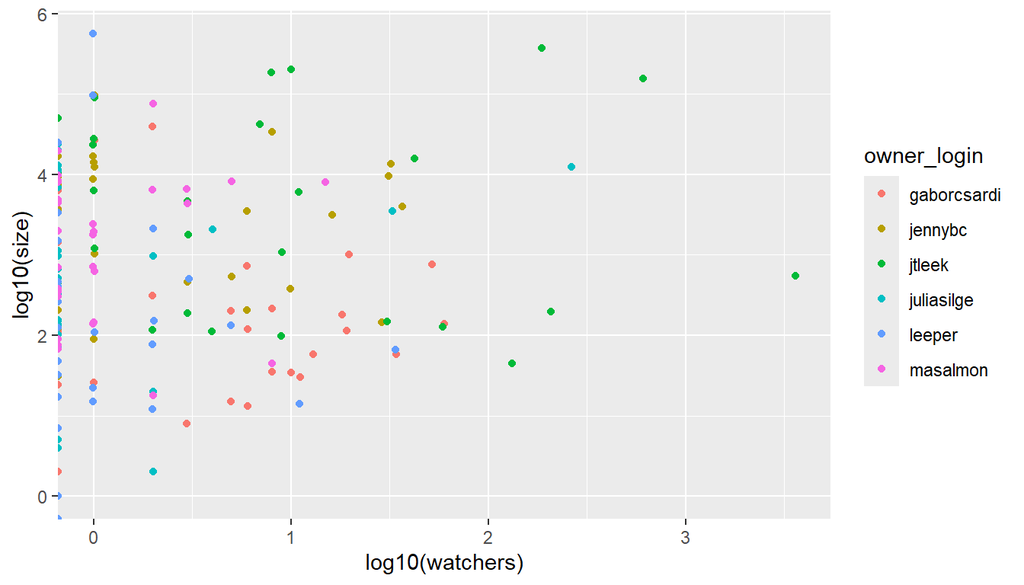

```r
gh_repos_df |>
  ggplot(mapping = aes(x = log10(watchers), y = log10(size))) +
  geom_jitter(mapping = aes(color = owner_login))
```

# When the JSON is a single object

## A different situation

`gh_repos` is a **list** of JSON objects, so `tibble()` turned it into a tibble with one row per entry.

If the file is exactly **one** JSON object, `tibble()` behaves differently. We can simulate this by taking a single object out of `gh_repos`:

```r
gh_repos_1 <- gh_repos[[1]][[1]]
```

```r
View(gh_repos_1)
```

## The problem

```r
tibble(data = gh_repos_1)
```

```
# A tibble: 68 × 1
   data
   <named list>
 1 <int [1]>
 2 <chr [1]>
 3 <chr [1]>
 4 <named list [17]>
 5 <lgl [1]>
 6 <chr [1]>
 7 <chr [1]>
 8 <lgl [1]>
 9 <chr [1]>
10 <chr [1]>
# ℹ 58 more rows
```

**The field names are missing**

We get a tibble with one column, whose rows are the fields of the object. The most unsatisfying part is that the **names of the fields are completely missing**.

## The fix

Force the single object into a `list` with one entry **before** making the tibble:

```r
(single_object <- tibble(data = list(gh_repos_1)))
```

```
# A tibble: 1 × 1
  data
  <list>
1 <named list [68]>
```

Then `unnest_wider()` gives a one-row tibble, with each field as a column:

```r
single_object |>
  unnest_wider(col = data)
```

```
# A tibble: 1 × 68
        id name  full_name owner        private html_url description fork  url
     <int> <chr> <chr>     <list>       <lgl>   <chr>    <chr>       <lgl> <chr>
1 61160198 after gaborcsa… <named list> FALSE   https:/… Run Code i… FALSE http…
# ℹ 59 more variables: forks_url <chr>, keys_url <chr>,
#   collaborators_url <chr>, teams_url <chr>, hooks_url <chr>,
#   issue_events_url <chr>, events_url <chr>, assignees_url <chr>,
#   branches_url <chr>, tags_url <chr>, blobs_url <chr>, git_tags_url <chr>,
#   git_refs_url <chr>, trees_url <chr>, statuses_url <chr>,
#   languages_url <chr>, stargazers_url <chr>, contributors_url <chr>,
#   subscribers_url <chr>, subscription_url <chr>, commits_url <chr>, …
```

# Wrap-up

## Choosing the right tool

| Format | Read | Write | Good to know |
| --- | --- | --- | --- |
| `.csv` | `read_csv()` | `write_csv()` | Plain text, but column types are lost |
| Parquet | `read_parquet()` | `write_parquet()` | Binary, keeps column types |
| Excel | `read_excel()` | `write_xlsx()` | Packages `readxl` and `writexl` |
| JSON | `read_json()` |  | Nested; needs rectangling with `unnest_` functions |

## Key takeaways

- `read_csv()` has many arguments; use them when the default guess is wrong
- Use `id =` to keep track of which file each row came from
- `write_csv()` loses column types; `parquet` keeps them
- JSON is nested: look at the structure with `View()` or `str()` first
- Rectangle with `tibble()`, then `unnest_longer()` (rows) and `unnest_wider()` (columns)